# PA1 Assignment

#### 4. Make a histogram of the total number of steps taken each day and Calculate and report the mean and median total number of steps taken per day. Do these values differ from the estimates from the first part of the assignment? What is the impact of imputing missing data on the estimates of the total daily number of steps?

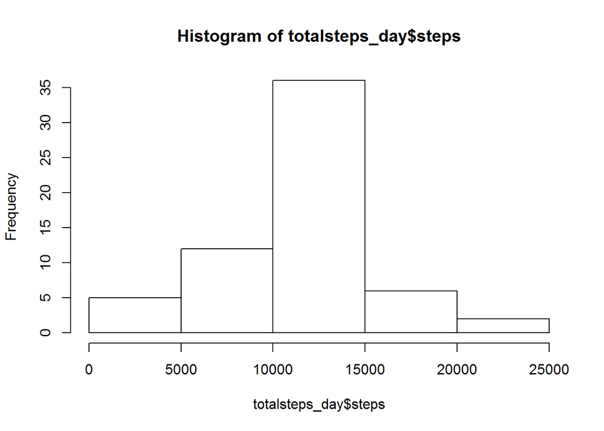

```r
totalsteps_day <- aggregate(steps ~ date, data=data, sum)
hist(totalsteps_day$steps)
```

```r
totalsteps_day_mean <- mean(totalsteps_day$steps)
totalsteps_day_mean
```

```
## [1] 10766.19
```

```r
meansteps_day
```

```
## [1] 10766.19
```

```r
totalsteps_day_median <- median(totalsteps_day$steps)
totalsteps_day_median
```

```
## [1] 10766.19
```

```r
mediansteps_day
```

```
## [1] 10765
```

```r
totalsteps_day_median - mediansteps_day
```

```
## [1] 1.188679
```

The mean steps/day did not change after imputing the mean value replacing the missing values. The median differed 1.188679 points.

## Are there differences in activity patterns between weekdays and weekends?

#### 1. Create a new factor variable in the dataset with two levels – “weekday” and “weekend” indicating whether a given date is a weekday or weekend day.

```r
totalsteps_day$weekdays <- weekdays(as.Date(totalsteps_day$date))
totalsteps_day$weekend <-as.factor(totalsteps_day$weekdays=="zaterday"|totalsteps_day$weekdays=="zondag")
levels(totalsteps_day$weekend) <- c("Weekday", "Weekend")
```

I tried but was unable to perform this last assignment. I somehow can’t get to produce the figure since my R is giving me the message that it doesn’t recognise the valuable “interval” and when I tried renaming the variables I had to define xlim values, but I can’t figure out what it means or how to do it. I tried the following (can’t put this in my R chunck because the system can’t knit errors): plot(steps ~ interval | date, data = totalsteps_day, type = “l”)

```r
View(totalsteps_day)

names(totalsteps_day) <- c("date", "steps", "weekdays", "interval")
View(totalsteps_day)


weekday_data <- totalsteps_day[totalsteps_day$weekdays=="Weekday",]
weekend_data <- totalsteps_day[totalsteps_day$weekend=="Weekend",]
```